# Proyecto Final Ciencia de Datos y Políticas Públicas

# Título: Reclamos y Arbolado en CABA

### Tema Reclamos por rotura de veredas y especies de árbol relacionadas

Pregunta de investigación ¿Existe alguna relación entre el tipo de especie de árbol y los reclamos de la ciudadanía por rotura de vereda a causa de raíces de árboles?

Fecha y área delimitada: CABA - en principio 2017 a 2019- para todas las comunas

### Objetivos

Objetivos Generales: Conocer si existe alguna relación entre el tipo de arbolado y la rotura de veredas en la ciudad

Objetivos Específicos: Saber qué tipos de especies son las que más causan roturas y cuales son las que menos daños causan

### Dificultades

-Trabajo colaborativo  
-Manejo de Features SF  
-Conseguir bases de datos fiscalizadas y normalizadas  
-Joinear tablas de Features  
-Mapear grandes datasets  
-Realizar correlaciones estadisticas con variables cualitativas

Para el siguiente proyecto utilizamos las librerias: -Tidyverse: Para el ordenamiento y manejo de los datos  
-SF: Para el manejo de la informacion georreferenciada  
-Knitr: para el manejo del Markdown  
-ggrepel: para el etiquetado en ggplot2

```r
library(tidyverse)
library(sf)
library(knitr)
library(ggrepel)
```

### Datasets

Utilizamos 2 Datasets en formato Shapefile (Este formato geografico permite tener una capa espacial georreferenciada asociada a un tabla): -Arbolado: Este dataset fue producido por la DG Arbolado a partir del Censo de Arbolado 2017-2018 -Reclamos: Este dataset fue provisto por la DG Reclamos de la Subsecretaria de Vias Peatonales

```r
Arbolado <- st_read("C:/Users/Lu G/Documents/Arbolado/Arbolado-20191017T185613Z-001/Arbolado/Arbolado_wgs84.shp", stringsAsFactors = FALSE)
Reclamos <- st_read("C:/Users/Lu G/Documents/Arbolado/Reclamos-20191017T190139Z-001/Reclamos/Reclamos_derivados_arbolado_wgs84_2.shp", stringsAsFactors = FALSE)
```

### 1.Arbolado de la Ciudad:

El dataset utilizado contiene todos los arboles existentes en la ciudad hacia 2018, relevados a partir de un censo. El censo detalla la posicion georreferenciada de cada arbol e informacion del mismo (Especie, Follaje, Origen, Altura, Diametro, Inclinacion, etc) En la Ciudad de Buenos Aires existen segun este censo 372.699 arboles. Muchos de estos, a partir de sus raices, generan roturas en las veredas de la ciudad que se traducen en dificultades para caminar la ciudad, problemas de accesibilidad para personas con movilidad reducida, caidas y litigios a partir de estas y costos economicos para la reparacion de las mismas.

```r
head(Arbolado)
```

```
## Simple feature collection with 6 features and 24 fields
## geometry type:  POINT
## dimension:      XY
## bbox:           xmin: -58.38966 ymin: -34.62006 xmax: -58.38906 ymax: -34.62003
## epsg (SRID):    4326
## proj4string:    +proj=longlat +datum=WGS84 +no_defs
##   OBJECTID TIPO_SITIO ID_ARBOL ALTURA_TOT DIAMETRO INCLINACIO ID_ESPECIE
## 1        1       Árbo     2430          7       20         17          1
## 2        2       Árbo     2431          8       33         16          1
## 3        3       Árbo     2432          2        3          0          9
## 4        4       Árbo     2433          9       17          0          7
## 5        5       Árbo     2434          6       13         14          1
## 6        6       Árbo     2435          3        2          0         28
##   NOMBRE_FAM NOMBRE_GEN             NOMBRE_CIE        NOMBRE_COM
## 1   Oleáceas   Fraxinus Fraxinus pennsylvanica  Fresno americano
```

[output cut: 26 more lines]

```r
summary(Arbolado)
```

```
##    OBJECTID          TIPO_SITIO          ID_ARBOL
##  Length:372699      Length:372699      Length:372699
##  Class :character   Class :character   Class :character
##  Mode  :character   Mode  :character   Mode  :character
##   ALTURA_TOT          DIAMETRO          INCLINACIO
##  Length:372699      Length:372699      Length:372699
##  Class :character   Class :character   Class :character
##  Mode  :character   Mode  :character   Mode  :character
##   ID_ESPECIE         NOMBRE_FAM         NOMBRE_GEN
##  Length:372699      Length:372699      Length:372699
##  Class :character   Class :character   Class :character
##  Mode  :character   Mode  :character   Mode  :character
##   NOMBRE_CIE         NOMBRE_COM         TIPO_FOLLA
##  Length:372699      Length:372699      Length:372699
##  Class :character   Class :character   Class :character
##  Mode  :character   Mode  :character   Mode  :character
##     ORIGEN           CODIGO_MAN         NOMBRE_BAR
##  Length:372699      Length:372699      Length:372699
##  Class :character   Class :character   Class :character
##  Mode  :character   Mode  :character   Mode  :character
##     CALLE              CHAPA1             CHAPA2
##  Length:372699      Length:372699      Length:372699
##  Class :character   Class :character   Class :character
##  Mode  :character   Mode  :character   Mode  :character
##    LONGITUD           LATITUD             CUSER
##  Length:372699      Length:372699      Length:372699
##  Class :character   Class :character   Class :character
##  Mode  :character   Mode  :character   Mode  :character
##     CDATE              MUSER              MDATE
##  Length:372699      Length:372699      Length:372699
##  Class :character   Class :character   Class :character
##  Mode  :character   Mode  :character   Mode  :character
##           geometry
##  POINT        :372699
##  epsg:4326    :     0
##  +proj=long...:     0
```

#### ¿Cuál son las especies que existen en la Ciudad de Buenos Aires?

Guiados por esta pregunta, agrupamos los arboles por especie y obtuvimos el porcentaje del total de arboles de la ciudad que representa. Por una cuestion de mayor familiaridad, extrajimos la tabla correspondiente al Shapefile de Arbolado en formato de texto plano .CSV

```r
write.csv(Arbolado, file = "C:/Users/Lu G/Documents/Arbolado/TB_Arbolado.csv", fileEncoding = 'UTF-8')
tb_arbol <- read.csv("C:/Users/Lu G/Documents/Arbolado/TB_Arbolado.csv", encoding = "UTF-8")
head(tb_arbol)
```

```
##   X OBJECTID TIPO_SITIO ID_ARBOL ALTURA_TOT DIAMETRO INCLINACIO ID_ESPECIE
## 1 1     Árbo       2430        7         20       17          1   Oleáceas
## 2 2     Árbo       2431        8         33       16          1   Oleáceas
## 3 3     Árbo       2432        2          3        0          9   Oleáceas
## 4 4     Árbo       2433        9         17        0          7  Aceráceas
## 5 5     Árbo       2434        6         13       14          1   Oleáceas
## 6 6     Árbo       2435        3          2        0         28   Rosáceas
##   NOMBRE_FAM             NOMBRE_GEN        NOMBRE_CIE
## 1   Fraxinus Fraxinus pennsylvanica  Fresno americano
## 2   Fraxinus Fraxinus pennsylvanica  Fresno americano
## 3  Ligustrum      Ligustrum lucidum          Ligustro
## 4       Acer           Acer negundo      Arce negundo
## 5   Fraxinus Fraxinus pennsylvanica  Fresno americano
## 6     Prunus      Prunus cerasifera Ciruelo de jardín
##                     NOMBRE_COM TIPO_FOLLA ORIGEN   CODIGO_MAN
```

[output cut: 20 more lines]

Con esa misma tabla realizamos el agrupamiento por especie:

```r
arbolado_cant <- tb_arbol %>%
  group_by(NOMBRE_CIE) %>%
  count(NOMBRE_CIE) %>%
  mutate(porcentaje_especie = (n*100)/372699) %>%
  arrange(desc(n))
```

Para poder visualizar sinteticamente el universo de arboles, generamos un ranking de las 10 especies de arboles mas comunes en la ciudad y lo graficamos:

```r
top10_esparboles <- filter(arbolado_cant, n > 9752) %>%
  arrange(desc(n))
top10 <- top10_esparboles$n
as.numeric(top10)
```

```
##  [1] 141825  34786  24558  24076  17477  11046  10537  10256   9788   9753
```

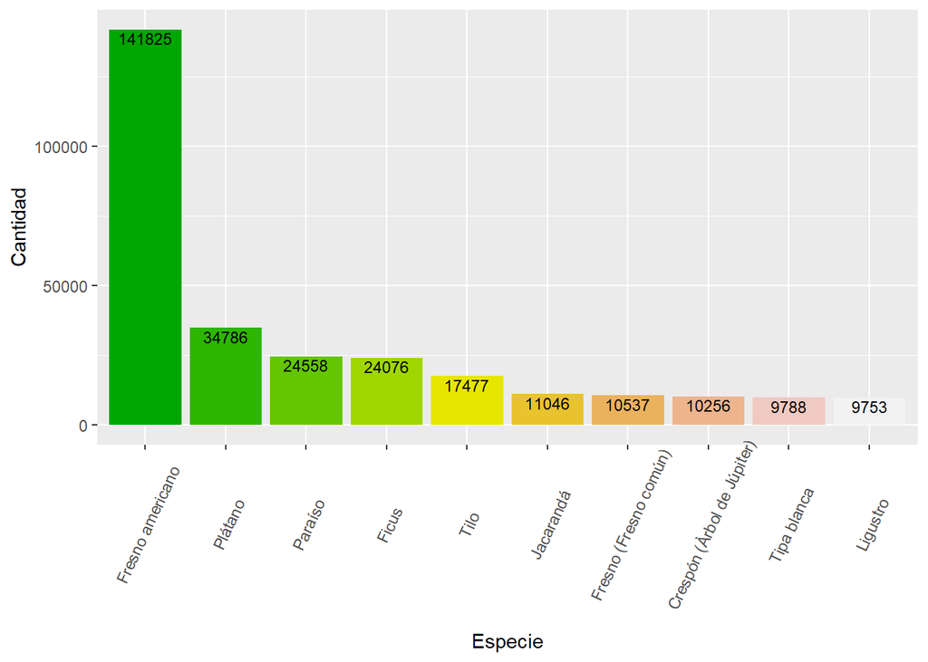

```r
top10_esparboles_plot <- factor(top10_esparboles, levels = top10_esparboles)
ggplot(top10_esparboles, aes(x=reorder(NOMBRE_CIE, -n), y=n)) +
  geom_bar(stat="identity", fill=terrain.colors(10)) +
  theme(axis.text.x = element_text(angle=65, vjust=0.6)) +
  geom_text(aes(label=n), vjust=1.2, size=3) +
  xlab("Especie") +
  ylab("Cantidad")
```

### 2.Reclamos

Este dataset se compone de los reclamos por rotura de veredas causadas por raices de arboles. Los reclamos fueron generados por los vecinos de la ciudad via SUACI entre Junio de 2016 y Enero de 2019. Estos reclamos fueron fiscalizados por la Subsecretaria de Vias Peatonales para relevar si efectivamente existia rotura y fueron derivados a DG Arbolado para su tratamiento. En total, consta de 11.289 reclamos verificados.

```r
head(Reclamos)
```

```
## Simple feature collection with 6 features and 16 fields
## geometry type:  POINT
## dimension:      XY
## bbox:           xmin: -58.50927 ymin: -34.64831 xmax: -58.45425 ymax: -34.59526
## epsg (SRID):    4326
## proj4string:    +proj=longlat +datum=WGS84 +no_defs
##          Aviso Fecha.de.a    Hora.del.a         Ubicaci.f3.n
## 1 S00686849/18 08/06/2018 11:58:09 p.m. B-VP-01033-05101-IMP
## 2 S01092919/18 04/09/2018 11:57:57 p.m. B-VP-08001-03651-IMP
## 3 S00873062/17 06/09/2017 11:56:24 p.m. B-VP-02046-01301-PAR
## 4 S00895067/17 13/09/2017 11:53:13 p.m. B-VP-06049-01001-IMP
## 5 S01348508/18 31/10/2018 11:51:32 p.m. B-VP-20088-02301-PAR
## 6 S00742105/17 30/07/2017 11:49:56 p.m. B-VP-13111-04142-PAR
##                                 Denominaci                   Descripci.f3.
## 1  ALBERDI, JUAN AV. 5101-5199 Acera Impar ALBERDI, JUAN BAUTISTA AV. 5127
```

[output cut: 26 more lines]

```r
summary(Reclamos)
```

```
##     Aviso            Fecha.de.a         Hora.del.a
##  Length:11289       Length:11289       Length:11289
##  Class :character   Class :character   Class :character
##  Mode  :character   Mode  :character   Mode  :character
##
##
##
##
##  Ubicaci.f3.n        Denominaci        Descripci.f3.
##  Length:11289       Length:11289       Length:11289
##  Class :character   Class :character   Class :character
##  Mode  :character   Mode  :character   Mode  :character
##
##
##
##
##   Status.de          Clase.de.a         Pto.tbjo.r
##  Length:11289       Length:11289       Length:11289
##  Class :character   Class :character   Class :character
##  Mode  :character   Mode  :character   Mode  :character
##
##
##
##
##   Grupo.plan            Orden           Creado.por
##  Length:11289       Min.   : 5205798   Length:11289
##  Class :character   1st Qu.: 8420884   Class :character
##  Mode  :character   Median : 8461310   Mode  :character
##                     Mean   : 8558630
##                     3rd Qu.: 8492993
##                     Max.   :60000507
##                     NA's   :9986
##   Hora.de.mo         Fin.desead         Modificado
##  Length:11289       Length:11289       Length:11289
##  Class :character   Class :character   Class :character
##  Mode  :character   Mode  :character   Mode  :character
##
##
##
##
##  Direcci.f3.n                geometry
##  Length:11289       POINT        :11289
##  Class :character   epsg:4326    :    0
##  Mode  :character   +proj=long...:    0
##
##
##
##
```

Mapa del Arbolado de la Ciudad de Buenos Aires

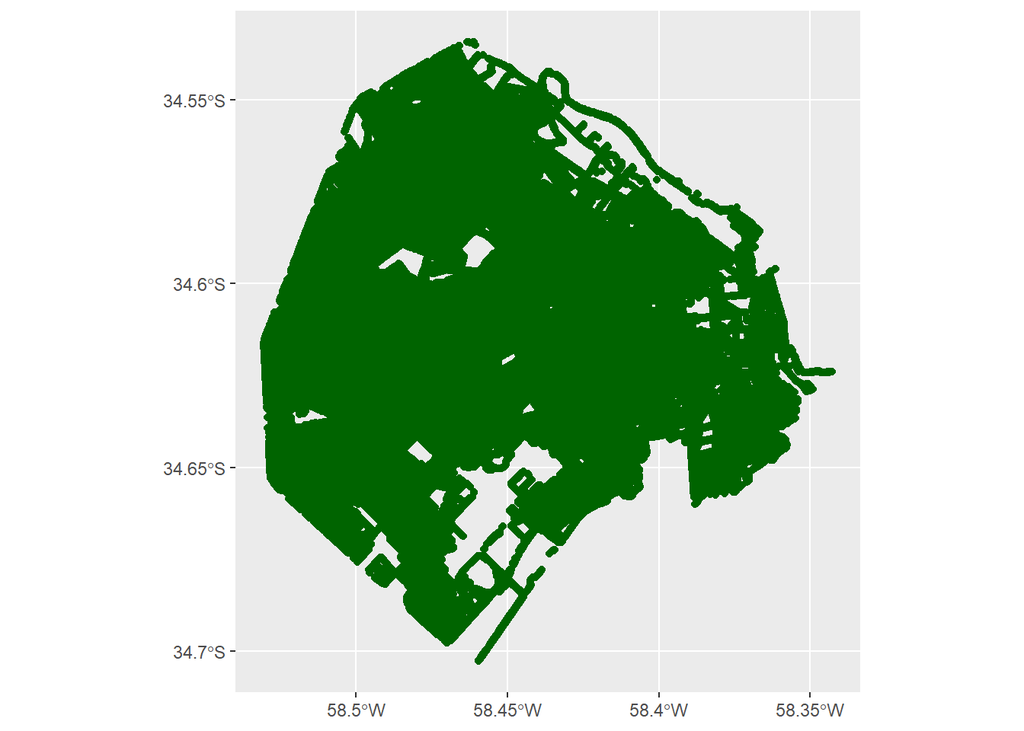

```r
arbolado_mapa <- summarise(Arbolado)
ggplot()+
  geom_sf(data = arbolado_mapa, colour = "Dark Green")
```

### Cruce de los Datos

En primer lugar, es necesario cruzar ambos datasets para conocer que arbol especifico genero el reclamo por rotura. Esto no esta identificado a priori en los datasets ya que no contienen ningun campo que los conecte entre si. La unica manera de generar este cruce es espacialmente. Es decir, encontrar el arbol correspondiente al reclamo a partir de una relacion espacial, en este caso, la cercania. Tomando cada reclamo generado a partir de sus coordenadas encontramos el arbol mas cercano.

```r
Index <- st_nearest_feature(Reclamos, Arbolado)
```

```
## although coordinates are longitude/latitude, st_nearest_feature assumes that they are planar
```

Este index, señala para cada Nº de fila en la base de reclamos el Nº de fila del arbol correspondiente

INDEX

| x |
| --- |
| 208346 |
| 90310 |
| 229627 |
| 62550 |
| 243474 |
| 365404 |
| 300563 |
| 59336 |
| 351955 |
| 154715 |

Sumamos el index al dataset de Reclamos en una nueva columna

| Direccion | Arbol | geometry |
| --- | --- | --- |
| ALBERDI, JUAN BAUTISTA AV. 5127 | 208346 | c(-58.4971438558396, -34.646545829748) |
| HABANA 3651 | 90310 | c(-58.5092728433408, -34.5952612292065) |
| BELAUSTEGUI, LUIS, DR. 1368 | 229627 | c(-58.459233175007, -34.6069233754069) |
| FRAGATA PRES. SARMIENTO 1015 | 62550 | c(-58.4542496708359, -34.6125614823545) |
| SEGUROLA AV. 2318 | 243474 | c(-58.5053779758706, -34.6149993059606) |

A partir de este index, que se convierte en un campo clave entre las dos bases podemos hacer un join entre ambas para continuar el analisis. Este paso, trajo algunas dificultades en el uso del Left Join de Dplyr en Tidyverse: -Al estar usando el formato Shapefile convertidos en features de SF, el join generaba un error por el tipo de archivo -La idea siguiente fue, convertir esa feature de SF en un Data Frame, el cual es un formato mas comun para trabajar en R -Esta vez, el Join no objetaba el formatato de archivo sino el formato de columna String para datos cuantitativos -Por lo cual, coercionamos la columna ID a formato Integer para poder realizar el Join Arbolado a Data Frame

```r
Arbolado2 <- as.data.frame(Arbolado)
```

ID a Campo Integer para Joinear

```r
Arbolado2 <- mutate(Arbolado2, id = rownames(Arbolado2))
#A integer
Arbolado2 <- mutate(Arbolado2, id = as.numeric(id))
```

Realizados los pasos anteriores, pudimos realizar el Left Join Join entre Reclamos y Arbolado por id arbol + cercano/Id arbol

```r
Reclamos_arb <- left_join(x = Reclamos_ind,y = Arbolado2, by = c("Arbol"="id"))
```

Este data frame devuelve una tabla en la que cada reclamo por rotura de raices tiene el arbol que lo genera y su informacion.

### Analisis de los resultados

¿Qué tipo de de árboles generan mayor cantidad de reclamos? Como habiamos realizado con la base de arbolado, tambien convertimos la base de Reclamos (Joineada con los respectivos arboles) a .CSV para mayor comodidad en el manejo de los datos. Eliminamos a su vez los campos de coordenadas que generaban errores en el procesamiento.

```r
Reclamos_arb_csv <- Reclamos_arb
Reclamos_arb_csv[42:44] <- list(NULL)
write.csv(Reclamos_arb_csv, file = "C:/Users/Lu G/Documents/Arbolado/TB_Reclamos_Arb.csv", fileEncoding = 'UTF-8')
tb_reclamos <- read.csv("C:/Users/Lu G/Documents/Arbolado/TB_Reclamos_Arb.csv", encoding = "UTF-8")
head(tb_reclamos)
```

```
##   X        Aviso Fecha.de.a    Hora.del.a         Ubicaci.f3.n
## 1 1 S00686849/18 08/06/2018 11:58:09 p.m. B-VP-01033-05101-IMP
## 2 2 S01092919/18 04/09/2018 11:57:57 p.m. B-VP-08001-03651-IMP
## 3 3 S00873062/17 06/09/2017 11:56:24 p.m. B-VP-02046-01301-PAR
## 4 4 S00895067/17 13/09/2017 11:53:13 p.m. B-VP-06049-01001-IMP
## 5 5 S01348508/18 31/10/2018 11:51:32 p.m. B-VP-20088-02301-PAR
## 6 6 S00742105/17 30/07/2017 11:49:56 p.m. B-VP-13111-04142-PAR
##                                 Denominaci                   Descripci.f3.
## 1  ALBERDI, JUAN AV. 5101-5199 Acera Impar ALBERDI, JUAN BAUTISTA AV. 5127
## 2             HABANA 3651-3699 Acera Impar                     HABANA 3651
## 3    BELAUSTEGUI, LUIS, DR. 1302-1400  Par     BELAUSTEGUI, LUIS, DR. 1368
## 4 FRAGATA PRES. SARMIENTO 1001-1099  Impar    FRAGATA PRES. SARMIENTO 1015
## 5         SEGUROLA AV. 2302-2350 Acera Par               SEGUROLA AV. 2318
## 6                MONTE 4142-4200 Acera Par                      MONTE 4166
##   Status.de Clase.de.a Pto.tbjo.r Grupo.plan   Orden Creado.por
```

[output cut: 55 more lines]

#### Arboles que generan roturas y Peso de la especie en los Reclamos

Agrupamos los reclamos generados en la ciudad a partir de la especie del arbol que lo genera y contamos el tamaño de cada grupo y su peso relativo sobre la totalidad de los reclamos Para un mejor entendimiento de la problematica trajimos a su vez la base de arboles por especie, con el fin de comparar el peso de la especie sobre los reclamos y sobre el arbolado en general

```r
Reclamos_arb_cant_nombre <- tb_reclamos %>%
  group_by(NOMBRE_COM)%>%
  count(NOMBRE_COM) %>%
  mutate(porcentaje_de_reclamos = (n*100)/11289) %>%
  arrange(desc(n))


Reclamos_arb_cant_nombre <- left_join(Reclamos_arb_cant_nombre, arbolado_cant, by = c("NOMBRE_COM"="NOMBRE_CIE"))
head(Reclamos_arb_cant_nombre)
```

```
## # A tibble: 6 x 5
## # Groups:   NOMBRE_COM [6]
##   NOMBRE_COM             n.x porcentaje_de_reclam~    n.y porcentaje_espec~
##   <chr>                <int>                 <dbl>  <int>             <dbl>
## 1 Fresno americano      4148                 36.7  141825             38.1
## 2 Plátano               1691                 15.0   34786              9.33
## 3 Paraíso                911                  8.07  24558              6.59
## 4 Tilo                   796                  7.05  17477              4.69
## 5 Ficus                  685                  6.07  24076              6.46
## 6 Fresno (Fresno comú~   419                  3.71  10537              2.83
```

#### Ranking de especies que generan reclamos

Utilizando como insumo el paso anterior podemos aislar las especies que mayor cantidad de reclamos generaron en la ciudad

```r
top10_esp_roturas <- filter(Reclamos_arb_cant_nombre, n.x > 167) %>%
  arrange(desc(n.x))
top10_esp_roturas
```

```
## # A tibble: 10 x 5
## # Groups:   NOMBRE_COM [10]
##    NOMBRE_COM               n.x porcentaje_de_recl~    n.y porcentaje_espe~
##    <chr>                  <int>               <dbl>  <int>            <dbl>
##  1 Fresno americano        4148               36.7  141825            38.1
##  2 Plátano                 1691               15.0   34786             9.33
##  3 Paraíso                  911                8.07  24558             6.59
##  4 Tilo                     796                7.05  17477             4.69
##  5 Ficus                    685                6.07  24076             6.46
##  6 Fresno (Fresno común)    419                3.71  10537             2.83
##  7 Tipa blanca              280                2.48   9788             2.63
##  8 Ligustro                 235                2.08   9753             2.62
##  9 Jacarandá                216                1.91  11046             2.96
## 10 Ligustro disciplinado~   176                1.56   9254             2.48
```

Sin embargo, este ranking no permite observar facilmente cuales son los arboles que MAS rompen las veredas con sus raices. Que una especie genere mayor cantidad de reclamos no tiene que ver solamente con sus caracteristicas, sino tambien con el tamaño de su poblacion en la ciudad. Por eso es necesario poner en perspectiva el “ranking” de especies que generan reclamos: Podriamos plantear la hipotesis de que: -Especie de arbol que mayor cantidad de roturas generan en las veredas de la ciudad son las que mayor porcentaje de SU propia poblacion genero reclamos en la ciudad. Entonces, buscamos las especies en las que es mayor el porcentaje de individuos que generan reclamos

```r
Especie_Comparacion <- Reclamos_arb_cant_nombre %>%
  mutate(Diferencia = porcentaje_de_reclamos-porcentaje_especie) %>%
  mutate(Porcentaje_Que_Rompe = (n.x*100)/n.y)
```

Tomando especies significativas (Mas de 500 arboles implantados en la Ciudad), podemos realizar un nuevo ranking. Este recorte de “especies significativas” es totalmente arbitrario pero permite dejar de lado poblaciones minimas de algunas especies en la CABA.

```r
Especie_Comparacion_Signif <- Especie_Comparacion %>%
  mutate(n.y = as.numeric(n.y)) %>%
  filter(n.y > 499 & NOMBRE_COM!="No Determinado") %>%
  arrange(desc(Porcentaje_Que_Rompe))
Especie_Comparacion_Signif
```

```
## # A tibble: 45 x 7
## # Groups:   NOMBRE_COM [45]
##    NOMBRE_COM   n.x porcentaje_de_r~   n.y porcentaje_espe~ Diferencia
##    <chr>      <int>            <dbl> <dbl>            <dbl>      <dbl>
##  1 Plátano     1691           15.0   34786            9.33     5.65
##  2 Tilo         796            7.05  17477            4.69     2.36
##  3 Fresno (F~   419            3.71  10537            2.83     0.884
##  4 Liquidamb~   158            1.40   4221            1.13     0.267
##  5 Paraíso      911            8.07  24558            6.59     1.48
##  6 Palo borr~    62            0.549  1750            0.470    0.0797
##  7 Sauce llo~    33            0.292   960            0.258    0.0347
##  8 Árbol del~    43            0.381  1411            0.379    0.00231
##  9 Álamo car~    58            0.514  1921            0.515   -0.00165
## 10 Morera bl~    20            0.177   667            0.179   -0.00180
## # ... with 35 more rows, and 1 more variable: Porcentaje_Que_Rompe <dbl>
```

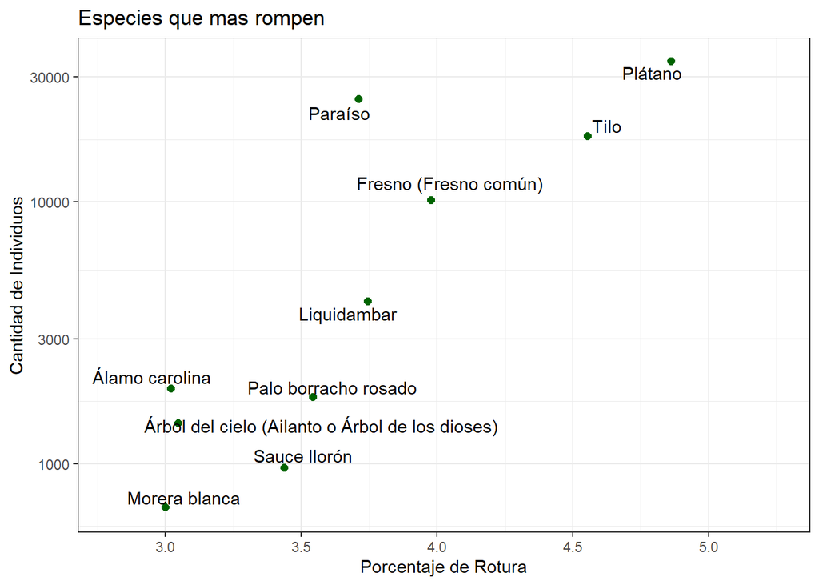

```r
Especies_Rotura <- Especie_Comparacion_Signif[1:10,]
theme_set(theme_bw())
ggplot(Especies_Rotura, aes(Especies_Rotura$Porcentaje_Que_Rompe, Especies_Rotura$n.y)) +
  geom_jitter(width = 0, size=2, color = "Dark Green") +
  geom_text_repel(label = Especies_Rotura$NOMBRE_COM) +
  labs(y="Cantidad de Individuos",
       x="Porcentaje de Rotura",
       title="Especies que mas rompen") +
  scale_y_log10() +
  xlim(c(2.8,5.25))
```

Y las especies que menos rompen son:

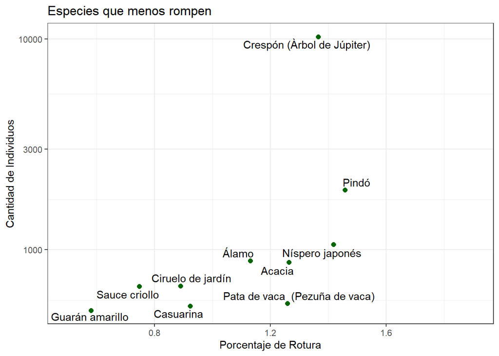

```r
Especies_menos_rotura <- Especie_Comparacion_Signif[36:45,] %>%
  arrange(Porcentaje_Que_Rompe)
theme_set(theme_bw())
ggplot(Especies_menos_rotura, aes(Especies_menos_rotura$Porcentaje_Que_Rompe, Especies_menos_rotura$n.y)) +
  geom_jitter(width =0, size=2, color = "Dark Green") +
  geom_text_repel(label = Especies_menos_rotura$NOMBRE_COM) +
  labs(y="Cantidad de Individuos",
       x="Porcentaje de Rotura",
       title="Especies que menos rompen") +
  scale_y_log10() +
  xlim(c(0.5,1.9))
```

### Conclusiones

Para profundizar, resta sumar variables como la altura o el diametro del arbol (datos presentes en el censo) y encontrar correlaciones estadisticas. Si bien contemplamos explorar algun tipo de correlacion, la realizacion de las mismas a partir de variables cualitativas implico un desarrollo al cual no pudimos dar respuesta aun. A su vez, obtener un universo mayor de reclamos y de roturas fiscalizadas en la Ciudad de Buenos Aires, e incluso en otros distritos, permitiria comprobar los resultados encontrados en este proyecto y mejorar el analisis y sus conclusiones.